# Influencia del ejercicio físico en la expresión génica humana: un enfoque bioinformático en la prevención del cáncer

Laura Yera Fernandez

2026-02-04

TFM_LauraYera | Máster Bioinformática

## Objetivo principal

- Analizar la expresión génica en un grupo de individuos sanos tras hacer ejercicio físico
- Dataset utilizado: GSE108643 de la plataforma GEPREP

```r
# Ver en qué carpeta se trabaja
getwd()
```

```
## [1] "/Users/laurayf/Desktop/UNIR/2Q/TFM/Datos"
```

```r
# Definir la carpeta donde se tienen los datos y se quiere trabajar
setwd("/Users/laurayf/Desktop/UNIR/2Q/TFM/Datos")
```

```r
# Cargar librerías básicas y necesarias
library(dplyr) # Librería para manipular datos
```

```r
library(readr) # Leer archivos
library(tibble) # Trabajar con tablas
library(tidyr) # Librería para manipular datos
library(ggplot2) # Librería para visualizar gráficos
library(limma) # Librería para analizar expresión
library(ggrepel) # Volcano Plot
library(pheatmap) # Librería para visualizar datos (heatmap)
library(stats) # PCA
library(factoextra) # visualización de PCA
library(clusterProfiler) # Librería de anotación
library(org.Hs.eg.db) # Librería de anotación
library(enrichplot) # Librería para dotplots
```

Los análisis se realizaron en R con la versión R version 4.4.3 2025-02-28, utilizando un conjunto de librerías necesarias para el análisis transcriptómico, incluyendo dplyr y tidyr para la manipulación de datos, ggplot para la visualización de gráficos, limma para el análisis diferencial de expresión con datos normalizados y pheatmap para la representación gráfica de resultados.

```r
# Cargar los datos del estudio de interés: GSE108643 (Plataforma GEPREP)
list.files() # Comprobar que se está en la carpeta correcta donde se encuentran los datos
```

```
##  [1] "Captura de pantalla 2025-12-27 a las 20.30.16.png"
##  [2] "DEGs.png"
##  [3] "geprep_data.txt"
##  [4] "GO_Biological_Process.png"
##  [5] "GO_BP_DEGs47.csv"
##  [6] "GO_BP_UP_DEGs.csv"
##  [7] "GO-BP_up_regulated_genes.png"
##  [8] "GSE108643_data.csv"
##  [9] "GSE108643_metadatos_normopeso.csv"
## [10] "GSE108643_metadatos.csv"
## [11] "Heatmap_1.png"
## [12] "Heatmap_2.png"
## [13] "Heatmap.png"
## [14] "KEGG_DEGs47.csv"
## [15] "KEGG_pathway_enrichment.png"
## [16] "limma_DEGs_filtered.csv"
## [17] "limma_results_all_genes.csv"
## [18] "PCA.png"
## [19] "tableExport.csv"
## [20] "TFM_LauraYera.html"
## [21] "TFM_LauraYera.Rmd"
## [22] "VolcanoPlot_etiquetado.png"
## [23] "VolcanoPlot_sin_etiquetar.png"
```

```r
# Primero se carga el archivo de metadatos descargado de la plataforma GEPREP
metadatos <- read.csv("tableExport.csv")
head(metadatos)
```

```
##   id  datasets        GSM     organism sample.title.in.GEO        SRR
## 1  1 GSE108643 GSM4008561 Homo sapiens          Lean Pre 1 SRR9906516
## 2  2 GSE108643 GSM4008562 Homo sapiens          Lean Pre 2 SRR9906517
## 3  3 GSE108643 GSM4008563 Homo sapiens          Lean Pre 3 SRR9906518
## 4  4 GSE108643 GSM4008564 Homo sapiens          Lean Pre 4 SRR9906519
## 5  5 GSE108643 GSM4008565 Homo sapiens          Lean Pre 5 SRR9906520
## 6  6 GSE108643 GSM4008566 Homo sapiens          Lean Pre 6 SRR9906521
##          SRX      source.name          tissue    sampling.site
## 1 SRX6657518 vastus lateralis skeletal muscle vastus lateralis
## 2 SRX6657519 vastus lateralis skeletal muscle vastus lateralis
## 3 SRX6657520 vastus lateralis skeletal muscle vastus lateralis
## 4 SRX6657521 vastus lateralis skeletal muscle vastus lateralis
## 5 SRX6657522 vastus lateralis skeletal muscle vastus lateralis
## 6 SRX6657523 vastus lateralis skeletal muscle vastus lateralis
##   extracted.molecule layout library.prepared.method health.status fitness
```

[output cut: 34 more lines]

```r
colnames(metadatos)
```

```
##  [1] "id"                       "datasets"
##  [3] "GSM"                      "organism"
##  [5] "sample.title.in.GEO"      "SRR"
##  [7] "SRX"                      "source.name"
##  [9] "tissue"                   "sampling.site"
## [11] "extracted.molecule"       "layout"
## [13] "library.prepared.method"  "health.status"
## [15] "fitness"                  "group"
## [17] "treatment"                "classification"
## [19] "exercise.type"            "protocol"
## [21] "duration"                 "frequency"
## [23] "intensity"                "biopsy.timepoint"
## [25] "gender"                   "age"
## [27] "exact.age"                "BMI"
## [29] "subject.id.or.sample.id." "susceptibility"
## [31] "exercise.response"        "platform.ID"
## [33] "instrument.model"
```

```r
# Comprobar que los metadatos solo corresponden al estudio de interés GSE108643
unique(metadatos$datasets)
```

```
## [1] "GSE108643"
```

```r
# Seleccionar y extraer las muestras de interés mediante la columna GSM
GSM_interes <- metadatos$GSM
GSM_interes
```

```
##  [1] "GSM4008561" "GSM4008562" "GSM4008563" "GSM4008564" "GSM4008565"
##  [6] "GSM4008566" "GSM4008567" "GSM4008568" "GSM4008569" "GSM4008570"
## [11] "GSM4008571" "GSM4008572" "GSM4008573" "GSM4008574" "GSM4008575"
## [16] "GSM4008576" "GSM4008577" "GSM4008578" "GSM4008579" "GSM4008580"
## [21] "GSM4008581" "GSM4008582" "GSM4008583" "GSM4008584" "GSM4008585"
## [26] "GSM4008586" "GSM4008587" "GSM4008588" "GSM4008590" "GSM4008591"
## [31] "GSM4008592" "GSM4008593" "GSM4008594" "GSM4008595" "GSM4008596"
## [36] "GSM4008597" "GSM4008598" "GSM4008599" "GSM4008600" "GSM4008601"
## [41] "GSM4008602" "GSM4008603" "GSM4008604" "GSM4008605" "GSM4008606"
## [46] "GSM4008607" "GSM4008608" "GSM4008609" "GSM4008610" "GSM4008611"
## [51] "GSM4008612" "GSM4008613" "GSM4008614" "GSM4008615" "GSM4008616"
## [56] "GSM4008617" "GSM4008618"
```

```r
# Comprobar cuantas muestras se tienen para el estudio
length(GSM_interes)
```

```
## [1] 57
```

```r
# Después se carga el archivo con todas las muestras humanas descargadas de GEPREP
geprep_data <- read.table(
  "geprep_data.txt",
  header = TRUE,
  sep = "\t",
  row.names = 1,
  check.names = FALSE,
  fill = TRUE,
  comment.char = "",
  quote = ""
)

# Mirar cuántos genes y muestras se tienen de forma global
dim(geprep_data)
```

```
## [1]  593 1120
```

```r
head(colnames(geprep_data)) # Revisar nombres de las columnas de geprep_data
```

```
## [1] "gene_name"  "GSM5841243" "GSM3417383" "GSM4977411" "GSM3417316"
## [6] "GSM2551348"
```

```r
sum(colnames(geprep_data) %in% metadatos$GSM) # Verificar que las muestras del dataset están en metadatos
```

```
## [1] 57
```

```r
length(metadatos$GSM)
```

```
## [1] 57
```

```r
# Filtrar y seleccionar solo las muestras de interés del estudio GSE108643
muestras_interes <- geprep_data[,
 c("gene_name", metadatos$GSM)
]

dim(muestras_interes)
```

```
## [1] 593  58
```

```r
# Poner los nombres de los genes de la columna gene_name como rownames
rownames(muestras_interes) <- muestras_interes$gene_name

# Asegurar que el orden de las muestras en la matriz de expresión coincide con el de los metadatos
muestras_interes <- muestras_interes[, metadatos$GSM]
all(colnames(muestras_interes) == metadatos$GSM)
```

```
## [1] TRUE
```

```r
# Comprobación básica de la estructura y del rango de valores
class(muestras_interes)
```

```
## [1] "data.frame"
```

```r
is.matrix(muestras_interes)
```

```
## [1] FALSE
```

```r
is.data.frame(muestras_interes)
```

```
## [1] TRUE
```

```r
str(muestras_interes[1:5, 1:5])
```

```
## 'data.frame':    5 obs. of  5 variables:
##  $ GSM4008561: num  27508 -17424 17330 15323 10392
##  $ GSM4008562: num  19990 30694 24353 40111 31453
##  $ GSM4008563: num  22548 1577 21227 16584 16876
##  $ GSM4008564: num  22041 -7066 19984 15766 15178
##  $ GSM4008565: num  20810 10618 29713 19286 19461
```

```r
range(muestras_interes, na.rm = TRUE)
```

```
## [1] -18704.99  65860.99
```

```r
# Guardar el csv de metadatos y de expresión génica de las muestras que pertenecen al estudio GSE108643
write.csv(
  muestras_interes,
  file = "GSE108643_data.csv",
  row.names = TRUE # Para que se guarde la primera columna con los gene_name
)

write.csv(
  metadatos,
  file = "GSE108643_metadatos.csv"
)
```

```r
# Se utilizan los archivos CSV generados para trabajar con ellos
expresion_genica <- read.csv(
  "GSE108643_data.csv",
  row.names = 1,
  check.names = FALSE
  )

metadatos <- read.csv("GSE108643_metadatos.csv") # En este archivo CSV se tienen ambos grupos: sanos y obesos

dim(expresion_genica)
```

```
## [1] 593  57
```

```r
dim(metadatos)
```

```
## [1] 57 34
```

```r
# Filtrar los datos por sujetos sanos que son los de interés
table(metadatos$group)
```

```
##
##  lean exercise Ov/Ob exercise
##             28             29
```

```r
metadatos_normopeso <- metadatos %>%
  filter(group == "lean exercise")

table(metadatos_normopeso$group)
```

```
##
## lean exercise
##            28
```

```r
# Guardar el CSV de metadatos_normopeso para filtrar solo por el grupo de interés
write.csv(
  metadatos_normopeso,
  file = "GSE108643_metadatos_normopeso.csv"
)
```

## Hacer PCA solo con sujetos normopeso (lean exercise) comparando pre y post ejercicio.

```r
metadatos_normopeso # Metadatos de los sujetos normopeso que son los de interés
```

```
##     X id  datasets        GSM     organism sample.title.in.GEO        SRR
## 1   1  1 GSE108643 GSM4008561 Homo sapiens          Lean Pre 1 SRR9906516
## 2   2  2 GSE108643 GSM4008562 Homo sapiens          Lean Pre 2 SRR9906517
## 3   3  3 GSE108643 GSM4008563 Homo sapiens          Lean Pre 3 SRR9906518
## 4   4  4 GSE108643 GSM4008564 Homo sapiens          Lean Pre 4 SRR9906519
## 5   5  5 GSE108643 GSM4008565 Homo sapiens          Lean Pre 5 SRR9906520
## 6   6  6 GSE108643 GSM4008566 Homo sapiens          Lean Pre 6 SRR9906521
## 7   7  7 GSE108643 GSM4008567 Homo sapiens          Lean Pre 7 SRR9906522
## 8   8  8 GSE108643 GSM4008568 Homo sapiens          Lean Pre 8 SRR9906523
## 9   9  9 GSE108643 GSM4008569 Homo sapiens          Lean Pre 9 SRR9906524
## 10 10 10 GSE108643 GSM4008570 Homo sapiens         Lean Pre 10 SRR9906525
## 11 11 11 GSE108643 GSM4008571 Homo sapiens         Lean Pre 11 SRR9906526
## 12 12 12 GSE108643 GSM4008572 Homo sapiens         Lean Pre 12 SRR9906527
## 13 13 13 GSE108643 GSM4008573 Homo sapiens         Lean Pre 13 SRR9906528
## 14 14 14 GSE108643 GSM4008574 Homo sapiens         Lean Pre 14 SRR9906529
```

[output cut: 188 more lines]

```r
expresion_genica # Expresión génica de todos los sujetos del estudio GSE108643, se debe seleccionar solo los normopeso
```

```
##                   GSM4008561   GSM4008562   GSM4008563   GSM4008564
## ACTA1           27507.787328 19990.270255 22548.353924 22040.779180
## MT-RNR2        -17423.930607 30693.580299  1577.383532 -7065.928581
## MT-CO1          17330.424785 24353.388935 21226.775776 19983.579641
## MT-CO3          15322.528616 40110.561395 16584.191601 15765.861635
## MT-ATP6         10391.509364 31453.228421 16875.685567 15177.638948
## RN7SL2           1253.694652   743.470639   106.117094  -325.529522
## MT-CO2          13566.577933 29756.400020 12568.980509 14367.569088
## MT-ND4           8910.894446 31197.544733 14701.654419 12604.366284
## RN7SL1             70.137471  -314.953211  -305.995415  -462.205645
## CKM             14871.124816 15142.431412 11226.724547 13748.815746
## MT-ND1           6886.563474 29384.461335  9233.347732 10344.872790
## MT-ATP8          7034.993538 10976.649705 11672.905616  8964.245391
## MT-ND3           6441.068370 23305.337192  9277.046193  9513.926636
## MT-RNR1         -6400.663268 17881.971646  2083.494736  1050.817381
## MT-CYB           7073.922165 23301.976719  8778.209289  8749.256488
## MT-ND4L          4760.954495  2704.076973 11657.940628  7836.201705
## MT-ND2           5115.842127 13306.812947  5707.024282  6175.115398
## RN7SK            2808.209658  3411.137732  2819.904482  2826.141019
## MB               9257.129883 10663.523438  7886.181152  7034.964355
## TPM2             7489.116822  8484.481763  7054.518302  6454.035721
## TNNC2            5583.657862  2534.997336  1797.040326  6928.723892
## MYL2             7762.170410 12898.071289 10661.104492  4454.302734
## MT-ND5           2771.101666  2919.240645  3854.034604  4177.806518
## TNNT1            6330.352539 10027.644744  8541.970823  3938.804841
## MYL1             4975.250000  8744.676758  5666.843262  4552.995117
## GAPDH            4342.082377  6093.397518  2393.601991  4590.099810
## TPT1             3918.327456  7896.030492  4557.355979  4591.243967
## ALDOA            4564.214222  5563.738834  2650.726093  4737.506174
## TNNC1            5270.115716  9104.420248  6500.374789  3021.488526
## DES              4230.006137  4446.329503  3908.284144  3259.255362
## MYLPF            3111.187383  2535.338526  2245.417741  4215.145243
## TNNT3            2121.953088  2896.685924  1768.564319  5227.187589
## MT-ND6           1480.581533  5641.829711  2388.710068  2553.514572
## ENO3             3272.255579  2742.196491  2175.454645  3373.912297
## TNNI2            2157.493404  1996.222821  1209.428878  4807.488999
## MT-TL1           1472.671510  5238.789419  1861.055797  3468.698735
## TPM1             2313.358885  2206.708653  1540.445881  3641.865987
## RMRP              418.765024   431.324291   287.095443   453.843982
## MYH2             4583.032227   885.510132  2557.426514  6486.241211
```

[output cut: 7667 more lines]

```
## EIF4B             95.0316656    66.633309    60.397003    66.464557
## IL32              32.2218607    13.382419    25.653446    53.923321
## COX7B             76.8342098    63.891802    80.607285    83.932065
## SIRT2             65.1987252    80.441612    88.666394    69.811844
## NGRN              79.2024454    87.358677   106.957546    99.926819
## CYBA              55.0447838    95.538351   221.155041   205.751763
## UCP3              41.6823156    62.865153    72.144910    36.742402
## SNTA1             85.6040134    77.362950    91.008364   100.071014
## RP11-290D2.6       0.0000000     0.000000     4.727501     0.000000
## MFN2              95.8851910    73.207537    61.119858    67.426073
## USO1              66.7578589    80.516260   126.214354    57.426129
## SBDS              66.8988739    61.824755    87.271056    86.694359
## SAT1             149.2759894   113.750324   284.706997   -64.521697
## EHBP1L1           98.6326548    62.140554    53.711508    70.676060
## CTD-2192J16.15            NA           NA    52.869206           NA
```

```r
meta_lean <- metadatos_normopeso %>%
  filter(group == "lean exercise") %>%
  transmute(
    GSM = GSM,
    subject_id = `subject.id.or.sample.id.`,
    timepoint = ifelse(biopsy.timepoint == "pre", "pre", "post")
  )

meta_lean$timepoint <- factor(meta_lean$timepoint, levels = c("pre", "post"))
table(meta_lean$timepoint)
```

```
##
##  pre post
##   14   14
```

```r
# Preparar la matriz de expresión
colnames(expresion_genica)
```

```
##  [1] "GSM4008561" "GSM4008562" "GSM4008563" "GSM4008564" "GSM4008565"
##  [6] "GSM4008566" "GSM4008567" "GSM4008568" "GSM4008569" "GSM4008570"
## [11] "GSM4008571" "GSM4008572" "GSM4008573" "GSM4008574" "GSM4008575"
## [16] "GSM4008576" "GSM4008577" "GSM4008578" "GSM4008579" "GSM4008580"
## [21] "GSM4008581" "GSM4008582" "GSM4008583" "GSM4008584" "GSM4008585"
## [26] "GSM4008586" "GSM4008587" "GSM4008588" "GSM4008590" "GSM4008591"
## [31] "GSM4008592" "GSM4008593" "GSM4008594" "GSM4008595" "GSM4008596"
## [36] "GSM4008597" "GSM4008598" "GSM4008599" "GSM4008600" "GSM4008601"
## [41] "GSM4008602" "GSM4008603" "GSM4008604" "GSM4008605" "GSM4008606"
## [46] "GSM4008607" "GSM4008608" "GSM4008609" "GSM4008610" "GSM4008611"
## [51] "GSM4008612" "GSM4008613" "GSM4008614" "GSM4008615" "GSM4008616"
## [56] "GSM4008617" "GSM4008618"
```

```r
rownames(expresion_genica)
```

```
##   [1] "ACTA1"          "MT-RNR2"        "MT-CO1"         "MT-CO3"
##   [5] "MT-ATP6"        "RN7SL2"         "MT-CO2"         "MT-ND4"
##   [9] "RN7SL1"         "CKM"            "MT-ND1"         "MT-ATP8"
##  [13] "MT-ND3"         "MT-RNR1"        "MT-CYB"         "MT-ND4L"
##  [17] "MT-ND2"         "RN7SK"          "MB"             "TPM2"
##  [21] "TNNC2"          "MYL2"           "MT-ND5"         "TNNT1"
##  [25] "MYL1"           "GAPDH"          "TPT1"           "ALDOA"
##  [29] "TNNC1"          "DES"            "MYLPF"          "TNNT3"
##  [33] "MT-ND6"         "ENO3"           "TNNI2"          "MT-TL1"
##  [37] "TPM1"           "RMRP"           "MYH2"           "FHL1"
##  [41] "MYH7"           "MYBPC1"         "SLN"            "RPPH1"
##  [45] "MT-TY"          "MT-TC"          "MT-TS1"         "TCAP"
##  [49] "TPM3"           "FTL"            "CA3"            "PYGM"
##  [53] "ATP2A1"         "HBB"            "KLHL41"         "RP5-857K21.11"
##  [57] "COX6A2"         "YBX3"           "MYOZ1"          "RN7SL3"
```

[output cut: 134 more lines]

```r
expr_mat <- as.matrix(expresion_genica)
storage.mode(expr_mat) <- "numeric"

# Ordenar los datos y poner las columnas de la matriz de expresión con el mismo orden que las filas del archivo meta_lean
# Vector con los IDs de muestra (en el orden correcto)
GSM_lean <- meta_lean$GSM

# Seleccionar solo esas columnas y en ese orden
expr_mat_lean <- expr_mat[, GSM_lean]

all(colnames(expr_mat_lean) == meta_lean$GSM) # Comprobar
```

```
## [1] TRUE
```

## PCA

El PCA se encarga de resumir miles de genes en unos pocos ejes para ver si las muestras se agrupan, por ejemplo, pre vs post.

```r
# Eliminar genes con varianza 0
var_genes <- apply(expr_mat_lean, 1, var) # Calcular varianza de cada gen
var_genes
```

```
##          ACTA1        MT-RNR2         MT-CO1         MT-CO3        MT-ATP6
##   1.213873e+07   4.236211e+08   2.217683e+07   2.891477e+07   2.265415e+07
##         RN7SL2         MT-CO2         MT-ND4         RN7SL1            CKM
##   4.835287e+05   1.510772e+07   2.154670e+07   2.525879e+04   3.339232e+06
##         MT-ND1        MT-ATP8         MT-ND3        MT-RNR1         MT-CYB
##   2.422004e+07   2.561064e+07   1.124918e+07   4.968482e+07   1.024347e+07
##        MT-ND4L         MT-ND2          RN7SK             MB           TPM2
##   1.147046e+07   6.288729e+06   3.105256e+04   1.533229e+06   1.237916e+06
##          TNNC2           MYL2         MT-ND5          TNNT1           MYL1
##   8.763187e+06   4.145659e+06   2.052831e+06   4.360868e+06   2.004560e+06
##          GAPDH           TPT1          ALDOA          TNNC1            DES
##   8.934631e+05   7.198675e+05   1.224102e+06   2.178298e+06   6.083152e+05
##          MYLPF          TNNT3         MT-ND6           ENO3          TNNI2
##   1.219150e+06   1.657917e+06   1.587027e+06   4.873291e+05   1.419712e+06
##         MT-TL1           TPM1           RMRP           MYH2           FHL1
##   3.266678e+06   7.903957e+05   6.599255e+03   1.805001e+06   2.084609e+05
##           MYH7         MYBPC1            SLN          RPPH1          MT-TY
##   8.675805e+05   2.812885e+05   2.207797e+05   1.469901e+03   1.024812e+06
##          MT-TC         MT-TS1           TCAP           TPM3            FTL
##   2.142206e+05   9.927077e+05   1.771304e+05   2.599237e+05   2.783286e+06
##            CA3           PYGM         ATP2A1            HBB         KLHL41
##   3.420952e+05   9.708011e+04   1.997224e+05   1.184644e+06   5.953137e+04
##  RP5-857K21.11         COX6A2           YBX3          MYOZ1         RN7SL3
##   5.135421e+05   6.676193e+04   6.556352e+04   2.509106e+04   0.000000e+00
##           MYL3          MT-TE          CRYAB          MT-TN            NEB
##   2.545079e+05   4.563993e+04   3.964843e+04   0.000000e+00   5.440796e+04
##        RNU2-2P          RPS11          RPLP1         S100A9           FTH1
##   4.744717e+02   1.364559e+05   4.726619e+04   5.012188e+05   1.695361e+05
##          CASQ1           MYH1          TNNI1         EEF1A2         PDLIM3
##   3.291303e+04   4.410987e+05   7.128947e+04   1.625600e+04   8.661175e+04
##          PGAM2         MYL12A           EEF2            B2M          RPS24
##   6.304748e+04   6.861803e+04   2.802346e+04   2.572867e+05   8.711105e+04
##            UBB         COX7A1   hsa-mir-6723          ACTN2          MT-TA
##   2.259809e+05   2.056342e+04   5.919628e+05   3.111820e+04   2.700334e-01
##           LDB3         MYBPC2         ATP2A2          RPS27          ATP5B
##   1.364281e+04   4.224659e+04   5.275185e+04   2.912577e+05   1.351337e+04
##            PKM          RPL30         S100A8          RPS29         RPL13A
##   2.073986e+04   9.005629e+04   2.029438e+05   1.191424e+05   3.388334e+04
##           NRAP          RPL19          HSPB1           RPL8           HBA1
##   5.478585e+04   2.365525e+04   7.480108e+04   1.406928e+04   5.020275e+01
```

[output cut: 183 more lines]

```
##   6.150494e+02   3.126461e+02   2.203551e+02   1.024241e+03   1.119261e+04
##        NDUFB11         MRFAP1          SYPL2          RAB7A      RN7SL431P
##   3.454539e+02   1.497731e+02   5.744476e+02   1.986663e+02   1.463968e+03
##          PSMB6        ATP6V0C         ANKRD1          PNRC1         HNRNPK
##   1.735308e+02   2.245598e+03   8.492919e+02   6.972168e+02   2.210643e+02
##         TALDO1       SNORA73B           RRAD         NDUFA6       C21orf33
##   3.755983e+03   0.000000e+00   1.104604e+04   2.702176e+02   7.817472e+02
##          YWHAG          XIRP1           ARF1          EIF4B           IL32
##   1.628177e+02   9.561108e+02   1.788821e+02   4.033035e+02   7.363333e+03
##          COX7B          SIRT2           NGRN           CYBA           UCP3
##   5.502233e+02   1.929952e+02   1.316465e+02   5.122642e+03   1.094117e+03
##          SNTA1   RP11-290D2.6           MFN2           USO1           SBDS
##   2.265485e+02   1.320983e+01   1.863508e+02   4.803844e+02   1.979125e+02
##           SAT1        EHBP1L1 CTD-2192J16.15
##   1.552645e+04   4.133442e+02             NA
```

```r
expr_mat_var <- expr_mat_lean[var_genes != 0, ] # Seleccionar solo los genes cuya varianza NO es cero

dim(expr_mat_lean)
```

```
## [1] 593  28
```

```r
dim(expr_mat_var)
```

```
## [1] 584  28
```

```r
# Eliminar genes con NA
sum(is.na(expr_mat_var))
```

```
## [1] 28
```

```r
expr_mat_clean <- expr_mat_var[complete.cases(expr_mat_var), ]
sum(is.na(expr_mat_clean))
```

```
## [1] 0
```

```r
# Calcular el PCA (las muestras tienen que estar en las filas.
pca <- prcomp(t(expr_mat_clean), scale. = FALSE) # scale. = FALSE porque los datos ya están normalizados y transformados por la plataforma GEPREP
summary(pca)
```

```
## Importance of components:
##                              PC1       PC2       PC3       PC4       PC5
## Standard deviation     2.151e+04 1.163e+04 6.787e+03 5931.6943 4.259e+03
## Proportion of Variance 6.167e-01 1.802e-01 6.141e-02    0.0469 2.418e-02
## Cumulative Proportion  6.167e-01 7.969e-01 8.583e-01    0.9052 9.294e-01
##                              PC6       PC7       PC8       PC9      PC10
## Standard deviation     3.900e+03 2.788e+03 2.493e+03 2.193e+03 1.799e+03
## Proportion of Variance 2.027e-02 1.036e-02 8.290e-03 6.410e-03 4.310e-03
## Cumulative Proportion  9.497e-01 9.600e-01 9.683e-01 9.747e-01 9.790e-01
##                             PC11      PC12      PC13      PC14      PC15
## Standard deviation     1.646e+03 1549.9274 1342.1181 1.219e+03 1.104e+03
## Proportion of Variance 3.610e-03    0.0032    0.0024 1.980e-03 1.630e-03
## Cumulative Proportion  9.827e-01    0.9859    0.9883 9.902e-01 9.919e-01
##                             PC16      PC17      PC18      PC19      PC20
## Standard deviation     1.087e+03 1.052e+03 855.27861 810.80259 702.61299
## Proportion of Variance 1.580e-03 1.480e-03   0.00098   0.00088   0.00066
## Cumulative Proportion  9.934e-01 9.949e-01   0.99589   0.99676   0.99742
##                             PC21      PC22      PC23      PC24      PC25
## Standard deviation     647.40460 633.56381 603.31476 495.49947 462.47728
## Proportion of Variance   0.00056   0.00054   0.00049   0.00033   0.00029
## Cumulative Proportion    0.99798   0.99852   0.99900   0.99933   0.99961
##                             PC26      PC27     PC28
## Standard deviation     399.18647 360.61587 3.72e-12
## Proportion of Variance   0.00021   0.00017 0.00e+00
## Cumulative Proportion    0.99983   1.00000 1.00e+00
```

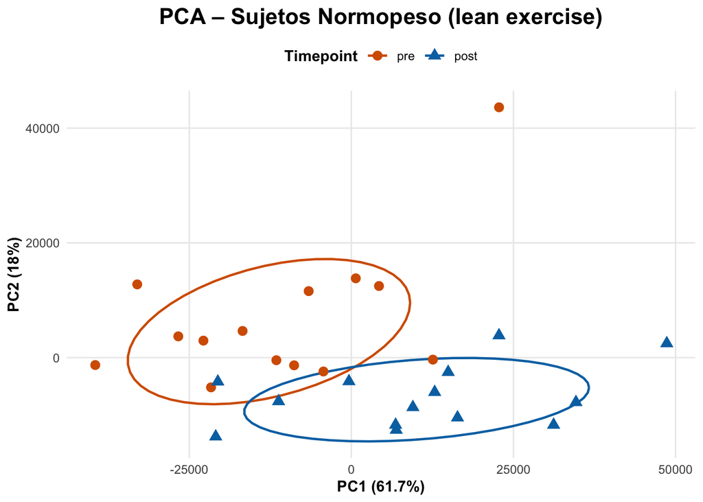

```r
# Datos para la representación del PCA
pca_df <- as.data.frame(pca$x)
pca_df$timepoint <- meta_lean$timepoint

# Porcentaje de varianza explicada
pca_var <- summary(pca)$importance[2, ] * 100

# Representación gráfica PCA
ggplot(pca_df, aes(x = PC1, y = PC2, color = timepoint, shape = timepoint)) +
  stat_ellipse(aes(group = timepoint), level = 0.68, linewidth = 0.8) +
  geom_point(size = 3) +
  scale_color_manual(values = c("pre" = "#D55E00", "post" = "#0072B2")) +
  scale_shape_manual(values = c("pre" = 16, "post" = 17)) +
  labs(
    title = "PCA – Sujetos Normopeso (lean exercise)",
    x = paste0("PC1 (", round(pca_var[1], 1), "%)"),
    y = paste0("PC2 (", round(pca_var[2], 1), "%)"),
    color = "Timepoint",
    shape = "Timepoint"
  ) +
  theme_minimal() +
  theme(
    plot.title = element_text(hjust = 0.5, face = "bold", size = 16),
    axis.title = element_text(face = "bold"),
    legend.title = element_text(face = "bold"),
    panel.grid.minor = element_blank(),
    legend.position = "top"
  )
```

## Estructura del experimento

El estudio consta de 14 sujetos sanos, de los cuales se tiene una muestra pre y otra post ejercicio para cada individuo. Por lo tanto, se trata de un diseño pareado, en el que las muestras pre y post ejercicio corresponden a las mismas personas. Esto hace que las muestras no deban tratarse como observaciones independientes, sino teniendo en cuenta la variabilidad intraindividual.

### Definición del factor experimental

Antes de realizar el análisis de expresión diferencial, fue necesario definir correctamente el diseño experimental y preparar los datos para su uso en el modelo estadístico. La variable timepoint se definió como un factor con dos niveles (pre y post), siendo la condición pre la de referencia. Esto permitió evaluar de forma directa los cambios en la expresión génica inducidos por el ejercicio físico.

```r
head(meta_lean)
```

```
##          GSM subject_id timepoint
## 1 GSM4008561     Lean 1       pre
## 2 GSM4008562     Lean 2       pre
## 3 GSM4008563     Lean 3       pre
## 4 GSM4008564     Lean 4       pre
## 5 GSM4008565     Lean 5       pre
## 6 GSM4008566     Lean 6       pre
```

```r
meta_lean$timepoint <- factor(
  meta_lean$timepoint,
  levels = c("pre", "post")
)
```

### Construcción del diseño estadístico

Se construyó una matriz de diseño que incluía el identificador del sujeto y el momento de la biopsia (pre y post), lo que permitió llevar a cabo una comparación pareada de la expresión génica y poder evaluar los cambios inducidos por el ejercicio físico.

En la matriz de diseño se incluye: - subject_id, para controlar la variabilidad individual (diseño pareado) - timepoint, para evaluar el efecto del ejercicio

```r
design <- model.matrix(~ subject_id + timepoint, data = meta_lean)
```

### Justificación del enfoque

Usar un diseño pareado, añadiendo el identificador del sujeto en el modelo estadístico, permite controlar las diferencias basales entre individuos y evaluar de una forma más precisa los cambios de expresión génica inducidos por el ejercicio. Es por ello, que este enfoque es adecuado cuando se estudian con muestras pre y post que provienen del mismo sujeto, ya que tiene en cuenta la variabilidad intraindividual y refleja correctamente el diseño experimental del estudio. En este punto, se deja definido el modelo estadístico que se utilizará en los análisis posteriores.

### Objetivo del siguiente paso

Una vez se definió el diseño estadístico, el siguiente paso consistió en aplicar un modelo lineal para identificar los genes diferencialmente expresados entre las condiciones pre y post ejercicio. Para ello, se utilizó el paquete limma, que permite estimar el efecto del ejercicio sobre la expresión génica y obtener, para cada gen, el cambio de expresión (logFC) y su significación stadística tras corrección por múltiples comparaciones. Los resultados obtenidos sirvieron como base para identificar aquellos genes diferencialmente expresados (DEGs), así como para su posterior visualización mediante volcano plots, heatmaps y el análisis funcional.

```r
# Ajustar el modelo lineal para cada gen
fit <- lmFit(expr_mat_clean, design)

# Aplicar Bayes empírico para estabilizar la estimación de la varianza
fit <- eBayes(fit)

# Tabla completa de resultados para el efecto post vs pre
results <- topTable(
  fit,
  coef = "timepointpost",
  number = Inf,
  adjust.method = "BH"
)
```

## Identificar genes diferencialmente expresados (DEGs)

```r
# Genes diferencialmente expresados
DEGs <- results[results$adj.P.Val < 0.05 & abs(results$logFC) > 0.5, ]

# Número total de genes diferencialmente expresados
nrow(DEGs)
```

```
## [1] 47
```

### Guardar resultados

```r
# Guardar los resultados en archivos CSV
write.csv(results, "limma_results_all_genes.csv", row.names = TRUE)
write.csv(DEGs, "limma_DEGs_filtered.csv", row.names = TRUE)
```

## Volcano Plot

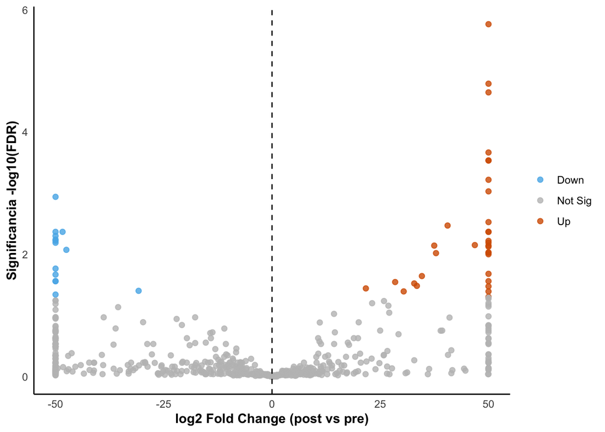

```r
# Preparar datos para el Volcano Plot (sin etiquetas de genes)
volcano_df <- as.data.frame(results)
volcano_df$gene <- rownames(results)
volcano_df$negLog10FDR <- -log10(volcano_df$adj.P.Val)

# Clasificar genes según su significancia y dirección de cambio
deg_genes <- rownames(DEGs)

volcano_df$status <- "Not Sig"
volcano_df$status[volcano_df$gene %in% deg_genes & volcano_df$logFC > 0] <- "Up"
volcano_df$status[volcano_df$gene %in% deg_genes & volcano_df$logFC < 0] <- "Down"

# Truncar logFC para la visualización (solo para el eje X)
cap <- 50
volcano_df$logFC_plot <- volcano_df$logFC
volcano_df$logFC_plot[volcano_df$logFC_plot >  cap] <-  cap
volcano_df$logFC_plot[volcano_df$logFC_plot < -cap] <- -cap

# Representación Volcano plot
gg_volcano <- ggplot(volcano_df, aes(x = logFC_plot, y = negLog10FDR)) +
  geom_point(aes(color = status), size = 1.8, alpha = 0.8) +
  scale_color_manual(
    values = c(
      "Down"    = "#56B4E9",
      "Not Sig" = "grey75",
      "Up"      = "#D55E00"
    ),
    name = NULL
  ) +
  geom_vline(xintercept = 0, linetype = "dashed") +
  labs(
    x = "log2 Fold Change (post vs pre)",
    y = "Significancia -log10(FDR)"
  ) +
  theme_minimal() +
  theme(
    panel.grid.major = element_blank(),
    panel.grid.minor = element_blank(),
    axis.line        = element_line(color = "black"),
    axis.title       = element_text(face = "bold"),
    legend.position  = "right"
  )

gg_volcano
```

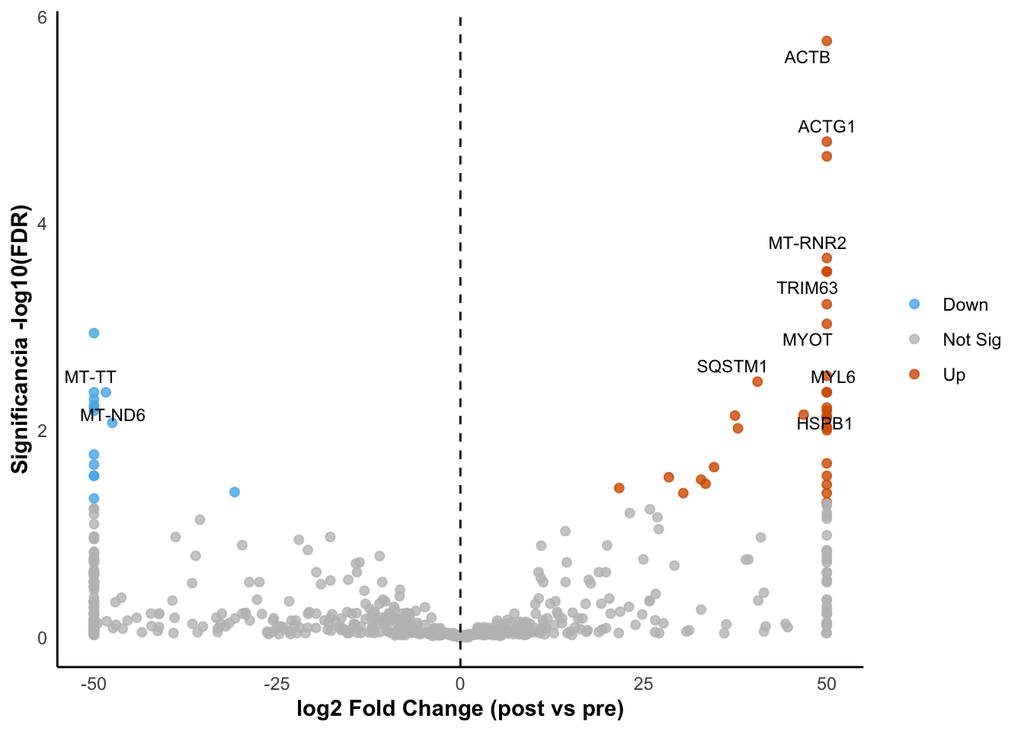

```r
# Volcano Plot con genes representativos
genes_interes <- c(
  "HSPB1", "SQSTM1", "TRIM63",
  "ACTB", "ACTG1", "MYOT", "MYL6",
  "MT-ND6", "MT-RNR2", "MT-TT"
)

label_df <- volcano_df %>%
  filter(gene %in% genes_interes)

gg_volcano_label <- gg_volcano +
  geom_text_repel(
    data = label_df,
    aes(x = logFC_plot, y = negLog10FDR, label = gene),
    size = 3,
  )

gg_volcano_label
```

Para facilitar la interpretación del Volcano Plot, se etiquetaron algunos de los genes representativos relacionados con procesos biológicos importantes, como la respuesta al estrés, la autofagia, la función mitocondrial y la estructura muscular.

## Heatmap de los 47 DEGs

```r
# Matriz de expresión de los 47 DEGs y escalado (z-score por gen)
expr_deg_47 <- expr_mat_clean[deg_genes, ]
expr_deg_47_scaled <- t(scale(t(expr_deg_47)))

# Ordenar columnas por sujeto y por timepoint (pre, post)
meta_lean$timepoint <- factor(meta_lean$timepoint,
                              levels = c("pre", "post"))
meta_lean$subject_num <- as.integer(gsub("Lean ", "", meta_lean$subject_id))

# Ordenar por factor subject_id (Lean 1, Lean 2, ..., Lean 14)
meta_lean$subject_id <- factor(
  meta_lean$subject_id,
  levels = paste0("Lean ", sort(unique(meta_lean$subject_num)))
)

# Ordenar las filas de meta_lean por sujeto y timepoint
meta_lean_ord <- meta_lean[order(meta_lean$subject_num, meta_lean$timepoint), ]

# Comprobar que todos los GSM existan en la matriz
all(meta_lean_ord$GSM %in% colnames(expr_deg_47_scaled))
```

```
## [1] TRUE
```

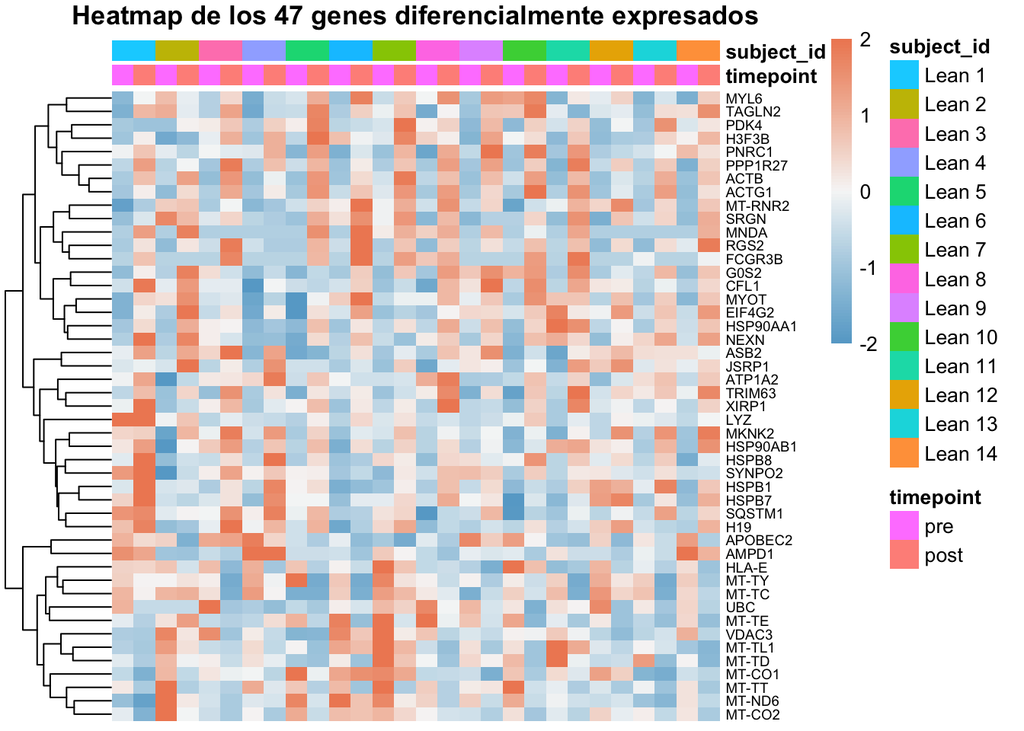

```r
# Reordenar columnas de la matriz de expresión según ese orden
expr_deg_47_scaled_ord <- expr_deg_47_scaled[, meta_lean_ord$GSM]

# Anotación de columnas (timepoint + subject_id)
annotation_col <- meta_lean_ord[, c("timepoint", "subject_id")]
rownames(annotation_col) <- meta_lean_ord$GSM

# Paleta de colores suave
my_cols <- colorRampPalette(c("#67a9cf", "#f7f7f7", "#ef8a62"))(100)

# Visualización Heatmap final de los 47 DEGs
pheatmap(
  expr_deg_47_scaled_ord,
  cluster_rows   = TRUE,    # agrupa genes por patrón de expresión
  cluster_cols   = FALSE,   # mantiene orden Lean1 pre/post, Lean2 pre/post, ...
  show_rownames  = TRUE,
  show_colnames  = FALSE,   # ocultamos GSM para no saturar
  annotation_col = annotation_col,
  color          = my_cols,
  breaks         = seq(-2, 2, length.out = 101),
  border_color   = NA,
  fontsize_row   = 7,
  main           = "Heatmap de los 47 genes diferencialmente expresados"
)
```

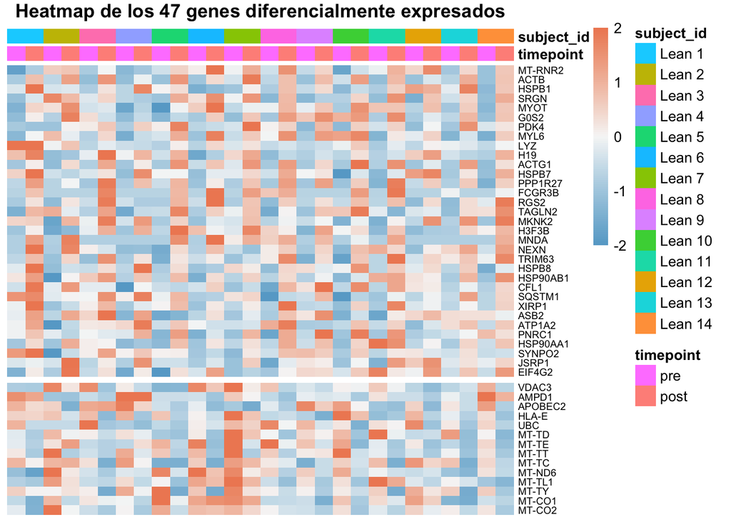

```r
# Heatmap de los 47 DEGs ordenados por logFC (up arriba / down abajo)

DEGs_ord <- DEGs[order(DEGs$logFC, decreasing = TRUE), ]
genes_ord <- rownames(DEGs_ord)

expr_deg_47_scaled_ord2 <- expr_deg_47_scaled_ord[genes_ord, ]
n_up   <- sum(DEGs_ord$logFC > 0)
n_down <- sum(DEGs_ord$logFC < 0)

# Visualización del heatmap
pheatmap(
  expr_deg_47_scaled_ord2,
  cluster_rows   = FALSE,   # mantenemos el orden por logFC
  cluster_cols   = FALSE,
  show_rownames  = TRUE,
  show_colnames  = FALSE,
  annotation_col = annotation_col,
  color          = my_cols,
  breaks         = seq(-2, 2, length.out = 101),
  border_color   = NA,
  fontsize_row   = 7,
  main           = "Heatmap de los 47 genes diferencialmente expresados",
  gaps_row       = n_up      # separa visualmente genes up vs down
)
```

Se generaron heatmaps a partir de los 47 DEGs identificados, para visualizar los patrones de expresión de los genes diferenialmente expresados. Los valores de expresión se escalaron por gen (z-score) para que fuese más sencillo comparar las muestras entre ellas. Además, las columnas se ordenaron por sujeto y momento de la biopsia (pre y post ejercicio), respetando el diseño pareado del estudio.

## Análisis funcional (GO/KEGG)

Una vez que se identificaron los genes diferencialmente expresados, se llevó a cabo un análisis funcional con la finalidad de interpretar los cambios observados en términos de procesos biológicos y rutas moleculares. Para ello, se aplicaron análisis de enriquecimiento utilizando las bases de datos de Gene Ontology (GO) y KEGG, que permitieron identificar funciones y vías que se representaban en el conjunto de genes modulados por el ejercicio.

```r
# Preparar lista de genes DEGs y universo (genes expresados) en ENTREZID
gene_symbols <- rownames(DEGs)
gene_df <- bitr(
  gene_symbols,
  fromType = "SYMBOL",
  toType   = "ENTREZID",
  OrgDb    = org.Hs.eg.db
)
gene_entrez <- unique(na.omit(gene_df$ENTREZID))

# Definir background, es decir, todos los genes expresados en expr_mat_clean
background_df <- bitr(
  rownames(expr_mat_clean),
  fromType = "SYMBOL",
  toType   = "ENTREZID",
  OrgDb    = org.Hs.eg.db
)
background_entrez <- unique(na.omit(background_df$ENTREZID))
```

Como universo de referencia para el análisis de enriquecimiento funcional se utilizó el conjunto de genes expresados en músculo esquelético en este estudio, que se definió a partir de la matriz de expresión después del preprocesado (expr_mat_clean). Esto permitió que se trabajara solamente con los genes que realmente se detectaron en el experimento, evitando que se introdujera información que no estaba presente en los datos. Tras el filtrado por expresión, se consideraron 583 genes como universo de referencia, de los cuales 479 pudieron asociarse a identificadores ENTREZ y fueron los utilizados en los análisis funcionales posteriores.

```r
# Gene Ontology: Biological Process (BP) con todos los DEGs
ego_bp <- enrichGO(
  gene          = gene_entrez,
  universe      = background_entrez,
  OrgDb         = org.Hs.eg.db,
  keyType       = "ENTREZID",
  ont           = "BP",
  pAdjustMethod = "BH",
  pvalueCutoff  = 0.05,
  qvalueCutoff  = 0.05,
  readable      = TRUE
)

# Ver los primeros términos GO
head(ego_bp)
```

```
##                    ID                                           Description
## GO:0048667 GO:0048667 cell morphogenesis involved in neuron differentiation
## GO:0048812 GO:0048812                       neuron projection morphogenesis
## GO:0048858 GO:0048858                         cell projection morphogenesis
## GO:0120039 GO:0120039 plasma membrane bounded cell projection morphogenesis
## GO:0030030 GO:0030030                          cell projection organization
## GO:0120036 GO:0120036  plasma membrane bounded cell projection organization
##            GeneRatio BgRatio RichFactor FoldEnrichment   zScore       pvalue
## GO:0048667      6/34  12/479        0.5       7.044118 5.855156 5.589868e-05
## GO:0048812      6/34  12/479        0.5       7.044118 5.855156 5.589868e-05
## GO:0048858      6/34  12/479        0.5       7.044118 5.855156 5.589868e-05
## GO:0120039      6/34  12/479        0.5       7.044118 5.855156 5.589868e-05
## GO:0030030      9/34  30/479        0.3       4.226471 5.040093 7.781180e-05
## GO:0120036      9/34  30/479        0.3       4.226471 5.040093 7.781180e-05
##               p.adjust     qvalue
## GO:0048667 0.009272573 0.00857295
## GO:0048812 0.009272573 0.00857295
## GO:0048858 0.009272573 0.00857295
## GO:0120039 0.009272573 0.00857295
## GO:0030030 0.009272573 0.00857295
## GO:0120036 0.009272573 0.00857295
##                                                          geneID Count
## GO:0048667                     ACTB/ACTG1/MYOT/CFL1/EIF4G2/NEXN     6
## GO:0048812                     ACTB/ACTG1/MYOT/CFL1/EIF4G2/NEXN     6
## GO:0048858                     ACTB/ACTG1/MYOT/CFL1/EIF4G2/NEXN     6
## GO:0120039                     ACTB/ACTG1/MYOT/CFL1/EIF4G2/NEXN     6
## GO:0030030 ACTB/ACTG1/RGS2/MYOT/CFL1/HSP90AA1/EIF4G2/VDAC3/NEXN     9
## GO:0120036 ACTB/ACTG1/RGS2/MYOT/CFL1/HSP90AA1/EIF4G2/VDAC3/NEXN     9
```

```r
as.data.frame(ego_bp)
```

```
##                    ID                                           Description
## GO:0048667 GO:0048667 cell morphogenesis involved in neuron differentiation
## GO:0048812 GO:0048812                       neuron projection morphogenesis
## GO:0048858 GO:0048858                         cell projection morphogenesis
## GO:0120039 GO:0120039 plasma membrane bounded cell projection morphogenesis
## GO:0030030 GO:0030030                          cell projection organization
## GO:0120036 GO:0120036  plasma membrane bounded cell projection organization
## GO:0031175 GO:0031175                         neuron projection development
## GO:0043412 GO:0043412                            macromolecule modification
##            GeneRatio BgRatio RichFactor FoldEnrichment   zScore       pvalue
## GO:0048667      6/34  12/479  0.5000000       7.044118 5.855156 5.589868e-05
## GO:0048812      6/34  12/479  0.5000000       7.044118 5.855156 5.589868e-05
## GO:0048858      6/34  12/479  0.5000000       7.044118 5.855156 5.589868e-05
## GO:0120039      6/34  12/479  0.5000000       7.044118 5.855156 5.589868e-05
## GO:0030030      9/34  30/479  0.3000000       4.226471 5.040093 7.781180e-05
## GO:0120036      9/34  30/479  0.3000000       4.226471 5.040093 7.781180e-05
## GO:0031175      7/34  21/479  0.3333333       4.696078 4.782902 2.761724e-04
## GO:0043412     12/34  61/479  0.1967213       2.771456 4.089598 3.713328e-04
##               p.adjust     qvalue
## GO:0048667 0.009272573 0.00857295
## GO:0048812 0.009272573 0.00857295
## GO:0048858 0.009272573 0.00857295
## GO:0120039 0.009272573 0.00857295
## GO:0030030 0.009272573 0.00857295
## GO:0120036 0.009272573 0.00857295
## GO:0031175 0.028209038 0.02608064
## GO:0043412 0.033187871 0.03068382
##                                                                                   geneID
## GO:0048667                                              ACTB/ACTG1/MYOT/CFL1/EIF4G2/NEXN
## GO:0048812                                              ACTB/ACTG1/MYOT/CFL1/EIF4G2/NEXN
## GO:0048858                                              ACTB/ACTG1/MYOT/CFL1/EIF4G2/NEXN
## GO:0120039                                              ACTB/ACTG1/MYOT/CFL1/EIF4G2/NEXN
## GO:0030030                          ACTB/ACTG1/RGS2/MYOT/CFL1/HSP90AA1/EIF4G2/VDAC3/NEXN
## GO:0120036                          ACTB/ACTG1/RGS2/MYOT/CFL1/HSP90AA1/EIF4G2/VDAC3/NEXN
## GO:0031175                                         ACTB/ACTG1/RGS2/MYOT/CFL1/EIF4G2/NEXN
## GO:0043412 ACTB/TRIM63/RGS2/MKNK2/HSP90AB1/SQSTM1/APOBEC2/HSPB1/ASB2/UBC/HSP90AA1/SYNPO2
##            Count
## GO:0048667     6
## GO:0048812     6
## GO:0048858     6
## GO:0120039     6
## GO:0030030     9
## GO:0120036     9
## GO:0031175     7
## GO:0043412    12
```

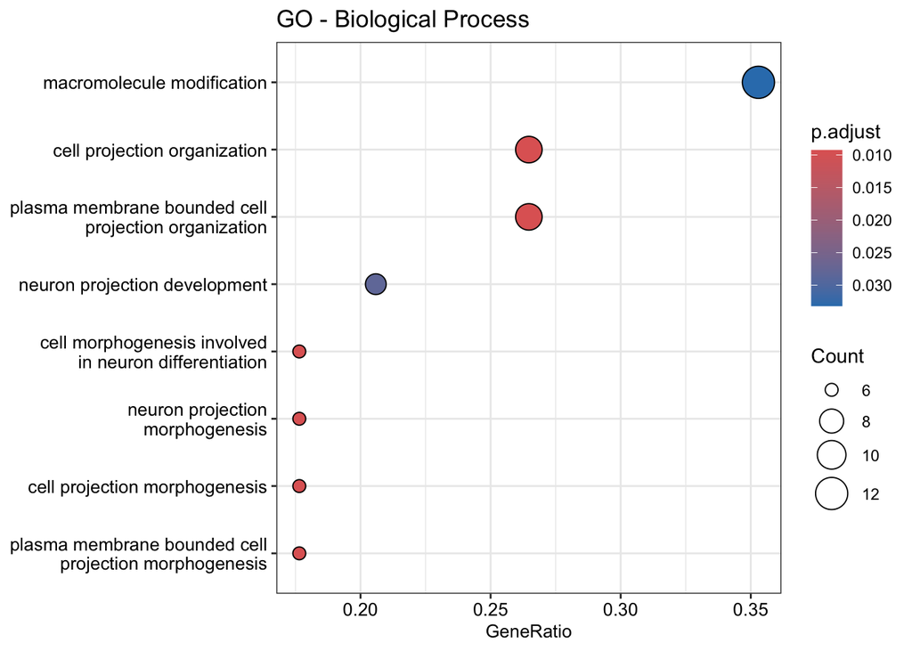

```r
# Dotplot GO BP (con términos significativos)
dotplot(ego_bp, showCategory = 10, font.size = 10) + ggtitle("GO - Biological Process")
```

```r
# Guardar resultados GO en un archivo CSV
ego_bp_df <- as.data.frame(ego_bp)
write.csv(ego_bp_df, file = "GO_BP_DEGs47.csv", row.names = FALSE)
```

### Justificación del Dotplot

En el análisis de enriquecimiento GO-BP se vieron procesos biológicos relacionados principalmente con la remodelación celular y la reorganización del citoesqueleto después de una sesión de ejercicio. Entre los términos que más se destacaron, se encontraron procesos relacionados con cambios en la arquitectura celular dependientes de actina y a la organización de estructuras celulares implicadas en la adaptación mecánica del músculo esquelético. Algunos de los términos enriquecidos aparecen normalmente en contextos no musculares, pero en este caso, reflejaron mecanismos celulares generales que también son importantes en músculo esquelético. La presencia de genes como ACTB, ACTG1, MYOT, CFL1 o NEXN sugirieron que el ejercicio agudo induce una respuesta orientada a la reorganización estructural y a procesos de adaptación asociados a la contracción muscular.

## GO estratificado por dirección de cambio

```r
# Separar los genes diferencialmente expresados por su dirección de cambio (up / down)
up_genes <- rownames(DEGs[DEGs$logFC > 0, ])
down_genes <- rownames(DEGs[DEGs$logFC < 0, ])

# GO-BP para genes UP
up_df <- bitr(
  up_genes,
  fromType = "SYMBOL",
  toType   = "ENTREZID",
  OrgDb    = org.Hs.eg.db
)
up_entrez <- unique(na.omit(up_df$ENTREZID))

ego_bp_up <- enrichGO(
  gene          = up_entrez,
  universe      = background_entrez,
  OrgDb         = org.Hs.eg.db,
  keyType       = "ENTREZID",
  ont           = "BP",
  pAdjustMethod = "BH",
  pvalueCutoff  = 0.05,
  qvalueCutoff  = 0.05,
  readable      = TRUE
)

head(ego_bp_up)
```

```
##                    ID                                           Description
## GO:0048667 GO:0048667 cell morphogenesis involved in neuron differentiation
## GO:0048812 GO:0048812                       neuron projection morphogenesis
## GO:0048858 GO:0048858                         cell projection morphogenesis
## GO:0120039 GO:0120039 plasma membrane bounded cell projection morphogenesis
## GO:0031175 GO:0031175                         neuron projection development
## GO:0030030 GO:0030030                          cell projection organization
##            GeneRatio BgRatio RichFactor FoldEnrichment   zScore       pvalue
## GO:0048667      6/29  12/479  0.5000000       8.258621 6.457925 2.090066e-05
## GO:0048812      6/29  12/479  0.5000000       8.258621 6.457925 2.090066e-05
## GO:0048858      6/29  12/479  0.5000000       8.258621 6.457925 2.090066e-05
## GO:0120039      6/29  12/479  0.5000000       8.258621 6.457925 2.090066e-05
## GO:0031175      7/29  21/479  0.3333333       5.505747 5.354888 9.181279e-05
## GO:0030030      8/29  30/479  0.2666667       4.404598 4.884386 1.571587e-04
##               p.adjust      qvalue
## GO:0048667 0.003657615 0.003223102
## GO:0048812 0.003657615 0.003223102
## GO:0048858 0.003657615 0.003223102
## GO:0120039 0.003657615 0.003223102
## GO:0031175 0.012853790 0.011326799
## GO:0030030 0.015715872 0.013848874
##                                                    geneID Count
## GO:0048667               ACTB/ACTG1/MYOT/CFL1/EIF4G2/NEXN     6
## GO:0048812               ACTB/ACTG1/MYOT/CFL1/EIF4G2/NEXN     6
## GO:0048858               ACTB/ACTG1/MYOT/CFL1/EIF4G2/NEXN     6
## GO:0120039               ACTB/ACTG1/MYOT/CFL1/EIF4G2/NEXN     6
## GO:0031175          ACTB/ACTG1/RGS2/MYOT/CFL1/EIF4G2/NEXN     7
## GO:0030030 ACTB/ACTG1/RGS2/MYOT/CFL1/HSP90AA1/EIF4G2/NEXN     8
```

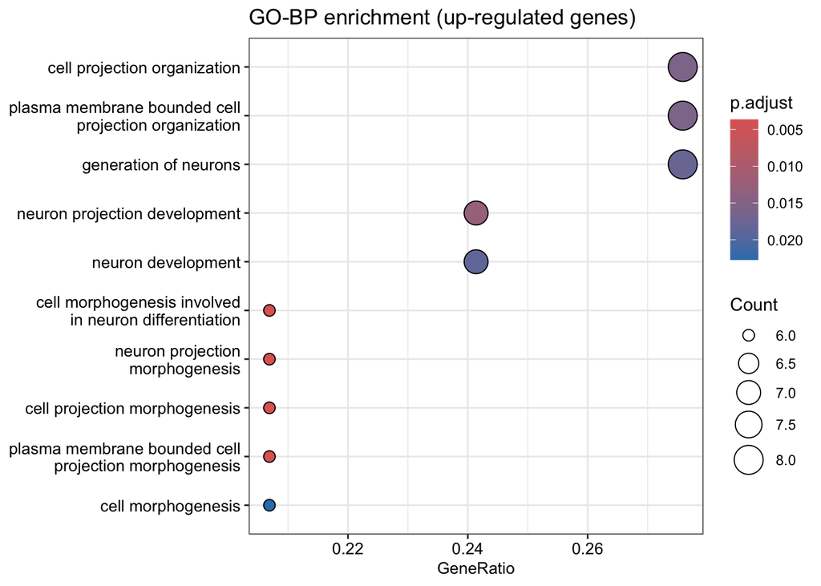

```r
# Dotplot para genes UP
dotplot(ego_bp_up, showCategory = 10, font.size = 10) + ggtitle("GO-BP enrichment (up-regulated genes)")
```

```r
# Guardar resultados GO a CSV (para anexos/GitHub)
ego_bp_up_df <- as.data.frame(ego_bp_up)
write.csv(ego_bp_up_df, file = "GO_BP_UP_DEGs.csv", row.names = FALSE)
```

```r
# GO-BP para genes DOWN
down_df <- bitr(
  down_genes,
  fromType = "SYMBOL",
  toType   = "ENTREZID",
  OrgDb    = org.Hs.eg.db
)
```

[figure not shown]

```r
down_entrez <- unique(na.omit(down_df$ENTREZID))

ego_bp_down <- enrichGO(
  gene          = down_entrez,
  universe      = background_entrez,
  OrgDb         = org.Hs.eg.db,
  keyType       = "ENTREZID",
  ont           = "BP",
  pAdjustMethod = "BH",
  pvalueCutoff  = 0.05,
  qvalueCutoff  = 0.05,
  readable      = TRUE
)

dotplot(ego_bp_down, showCategory = 10, font.size = 10) +
  ggtitle("GO-BP enrichment (down-regulated genes)")
```

```r
head(ego_bp_down)
```

```
##  [1] ID             Description    GeneRatio      BgRatio        RichFactor
##  [6] FoldEnrichment zScore         pvalue         p.adjust       qvalue
## [11] geneID         Count
## <0 rows> (or 0-length row.names)
```

En conjunto, el análisis GO-BP nos informa de la respuesta transcriptómica al ejercicio agudo en músculo esquelético, la cual se centra en procesos de remodelación estructural y reorganización del citoesqueleto, que tienen coherencia con la adaptación mecánica después de la contracción. Al separar los genes según su dirección de cambio, el enriquecimiento se observa sobre todo en los genes sobreexpresados, mientras que en los genes infraexpresados no se detectaron términos significativos, probablemente por tener un menos número de genes en este grupo. Para complementar el análisis GO, se realizó un análisis de enriquecimiento de rutas utilizando la base de datos KEGG, permitiendo identificar conjuntos de genes que participan conjuntamente en rutas moleculares específicas y facilita la interpretación de los cambios transcriptómicos a nivel de vías biológicas.

## KEGG

```r
# KEGG con todos los DEGs
ekegg <- enrichKEGG(
  gene          = gene_entrez,
  universe      = background_entrez,
  organism      = "hsa",
  pvalueCutoff  = 0.05
)
```

```
## Reading KEGG annotation online: "https://rest.kegg.jp/link/hsa/pathway"...
```

```
## Reading KEGG annotation online: "https://rest.kegg.jp/list/pathway/hsa"...
```

```r
# Ver primeros resultados KEGG
head(ekegg)
```

```
##                    category                   subcategory       ID
## hsa05418     Human Diseases        Cardiovascular disease hsa05418
## hsa04217 Cellular Processes         Cell growth and death hsa04217
## hsa05416     Human Diseases        Cardiovascular disease hsa05416
## hsa04145 Cellular Processes      Transport and catabolism hsa04145
## hsa04921 Organismal Systems              Endocrine system hsa04921
## hsa05131     Human Diseases Infectious disease: bacterial hsa05131
##                                     Description GeneRatio BgRatio RichFactor
## hsa05418 Fluid shear stress and atherosclerosis      5/23  12/369  0.4166667
## hsa04217                            Necroptosis      4/23  10/369  0.4000000
## hsa05416                      Viral myocarditis      4/23  11/369  0.3636364
## hsa04145                              Phagosome      4/23  13/369  0.3076923
## hsa04921             Oxytocin signaling pathway      4/23  14/369  0.2857143
## hsa05131                            Shigellosis      4/23  14/369  0.2857143
##          FoldEnrichment   zScore       pvalue   p.adjust     qvalue
## hsa05418       6.684783 5.154899 0.0003574427 0.01429771 0.01015890
## hsa04217       6.417391 4.471907 0.0018951414 0.03790283 0.02693096
## hsa05416       5.833992 4.190931 0.0028537764 0.03805035 0.02703578
## hsa04145       4.936455 3.720504 0.0056775937 0.04352353 0.03092461
## hsa04921       4.583851 3.520056 0.0076166175 0.04352353 0.03092461
## hsa05131       4.583851 3.520056 0.0076166175 0.04352353 0.03092461
##                        geneID Count
## hsa05418 60/71/3326/8878/3320     5
## hsa04217  3326/8878/3320/7419     4
## hsa05416      60/71/3133/1982     4
## hsa04145      60/71/3133/2215     4
## hsa04921      60/71/5997/4637     4
## hsa05131      60/71/8878/7316     4
```

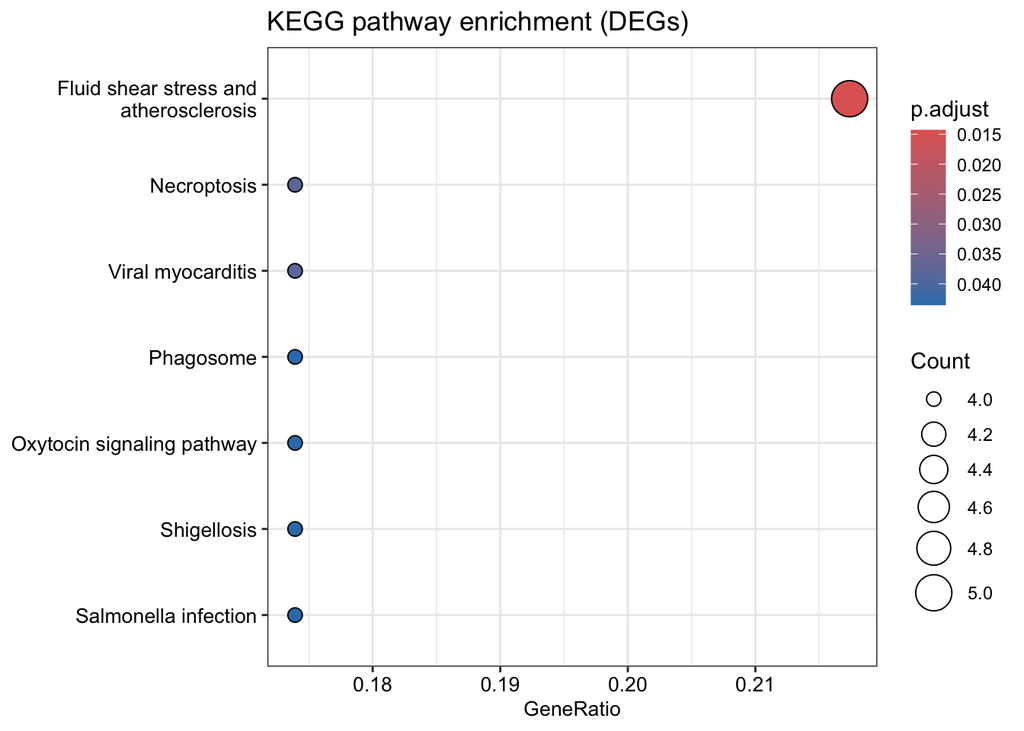

```r
# Dotplot del resultado KEGG
dotplot(ekegg, showCategory = 10, font.size = 10) + ggtitle("KEGG pathway enrichment (DEGs)")
```

```r
# Guardar resultados KEGG en un archivo CSV
ekegg_df <- as.data.frame(ekegg)
write.csv(ekegg_df, file = "KEGG_DEGs47.csv", row.names = FALSE)
```

En el análisis KEGG se observaron que muchos de los genes que cambian tras el ejercicio están relacionados con cómo la célula responde al estrés y a las fuerzas mecánicas que se generan durante la contracción muscular. Esto tiene sentido si se tiene en cuenta que el músculo, al ejercitarse, se ve sometido a tensiones físicas y a cambios en su equilibrio interno. Algunas de las rutas que aparecen enriquecidas suelen estar descritas en contextos de enfermedad o inflamación, pero en este caso, no indican un proceso patológico, sino que reflejan mecanismos generales que la célula utilza para adaptarse y responder a un estímulo intenso como el ejercicio. En resumen, estos resultados apoyan la idea de que el ejercicio agudo no provoca cambios drásticos en todos los genes, sino pequeños ajustes concretos y coordinados en algunas vías clave que ayudan al músculo a adaptarse después del esfuerzo.